# Genome annotation with `prokka`

Now that we have some extra information about our bins, we can continue to analyse the high-quality bins. The final CheckM results will give you a good overview of the bins with low contamination and high completeness and show the bin's lowest taxonomic rank. Pick a bin that you think is interesting to study further. Alternatively, you may also make a loop to annotate multiple bins.

With this selected bin(s), we are going to do genome annotation. Whole-genome annotation is the process of identifying features of interest in a set of genomic DNA sequences and labelling them with useful information. `Prokka` is a software tool to annotate bacterial, archaeal and viral genomes quickly and produce standards-compliant output files.

**[DO:] make a directory for the** `prokka` **output:**

```bash
mkdir data/annotation
```

**[DO:] read the prokka help page** Remember to look for the usage line.

```bash
prokka -h
```

```
Option h is ambiguous (help, hmms)
Name:
  Prokka 1.13 by Torsten Seemann <torsten.seemann@gmail.com>
Synopsis:
  rapid bacterial genome annotation
Usage:
  prokka [options] <contigs.fasta>
General:
  --help            This help
  --version         Print version and exit
  --docs            Show full manual/documentation
  --citation        Print citation for referencing Prokka
  --quiet           No screen output (default OFF)
  --debug           Debug mode: keep all temporary files (default OFF)
Setup:
  --listdb          List all configured databases
  --setupdb         Index all installed databases
  --cleandb         Remove all database indices
  --depends         List all software dependencies
Outputs:
  --outdir [X]      Output folder [auto] (default '')
  --force           Force overwriting existing output folder (default OFF)
  --prefix [X]      Filename output prefix [auto] (default '')
  --addgenes        Add 'gene' features for each 'CDS' feature (default OFF)
  --addmrna         Add 'mRNA' features for each 'CDS' feature (default OFF)
  --locustag [X]    Locus tag prefix [auto] (default '')
  --increment [N]   Locus tag counter increment (default '1')
  --gffver [N]      GFF version (default '3')
  --compliant       Force Genbank/ENA/DDJB compliance: --addgenes --mincontiglen 200 --centre XXX (default OFF)
  --centre [X]      Sequencing centre ID. (default '')
  --accver [N]      Version to put in Genbank file (default '1')
Organism details:
  --genus [X]       Genus name (default 'Genus')
  --species [X]     Species name (default 'species')
  --strain [X]      Strain name (default 'strain')
  --plasmid [X]     Plasmid name or identifier (default '')
Annotations:
  --kingdom [X]     Annotation mode: Archaea|Bacteria|Mitochondria|Viruses (default 'Bacteria')
  --gcode [N]       Genetic code / Translation table (set if --kingdom is set) (default '0')
  --gram [X]        Gram: -/neg +/pos (default '')
  --usegenus        Use genus-specific BLAST databases (needs --genus) (default OFF)
  --proteins [X]    FASTA or GBK file to use as 1st priority (default '')
  --hmms [X]        Trusted HMM to first annotate from (default '')
  --metagenome      Improve gene predictions for highly fragmented genomes (default OFF)
  --rawproduct      Do not clean up /product annotation (default OFF)
  --cdsrnaolap      Allow [tr]RNA to overlap CDS (default OFF)
Computation:
  --cpus [N]        Number of CPUs to use [0=all] (default '8')
  --fast            Fast mode - only use basic BLASTP databases (default OFF)
  --noanno          For CDS just set /product="unannotated protein" (default OFF)
  --mincontiglen [N] Minimum contig size [NCBI needs 200] (default '1')
  --evalue [n.n]    Similarity e-value cut-off (default '1e-06')
  --rfam            Enable searching for ncRNAs with Infernal+Rfam (SLOW!) (default '0')
  --norrna          Don't run rRNA search (default OFF)
  --notrna          Don't run tRNA search (default OFF)
  --rnammer         Prefer RNAmmer over Barrnap for rRNA prediction (default OFF)
(metagenomics_practical)
```

Use the options `--centre X --compliant` to stop prokkas complaints about ugly contig names.

**[DO:] run prokka:** This may take a while.

```bash
prokka data/bins/bin.1.fa --outdir data/annotation/bin1  --cpus 1 --centre X --compliant
```

[output not shown]

[output cut: 891 more lines]

```
[16:40:40] data/annotation/bin1/PROKKA_03222022.ffn
[16:40:40] data/annotation/bin1/PROKKA_03222022.tbl
[16:40:40] data/annotation/bin1/PROKKA_03222022.fsa
[16:40:40] data/annotation/bin1/PROKKA_03222022.tsv
[16:40:40] data/annotation/bin1/PROKKA_03222022.txt
[16:40:40] data/annotation/bin1/PROKKA_03222022.sqn
[16:40:40] data/annotation/bin1/PROKKA_03222022.err
[16:40:40] data/annotation/bin1/PROKKA_03222022.gbk
[16:40:40] Annotation finished successfully.
[16:40:40] Walltime used: 6.00 minutes
[16:40:40] If you use this result please cite the Prokka paper:
[16:40:40] Seemann T (2014) Prokka: rapid prokaryotic genome annotation. Bioinformatics. 30(14):2068-9.
[16:40:40] Type 'prokka --citation' for more details.
[16:40:40] Thank you, come again.
(metagenomics_practical)
```

## Investigating prokka output

The prokka output is very elaborate and can be used to many ends. We will quickly visualise the output for the purpose of this practical. To investigate the prokka output, you can use two webservers that both can place the annotations from prokka in metabolic KEGG pathways. First, we'll inspect the contents of a GFF file.

**[DO:] View prokka output:** (look for the `.gff` file)

```bash
ls data/annotation/bin1
```

```
PROKKA_03222022.err  PROKKA_03222022.fsa  PROKKA_03222022.sqn
PROKKA_03222022.faa  PROKKA_03222022.gbk  PROKKA_03222022.tbl
PROKKA_03222022.ffn  PROKKA_03222022.gff  PROKKA_03222022.tsv
PROKKA_03222022.fna  PROKKA_03222022.log  PROKKA_03222022.txt
(metagenomics_practical)
```

```bash
head data/annotation/bin1/PROKKA_03222022.txt
```

```
organism: Genus species strain
contigs: 37
bases: 4425020
gene: 4339
tRNA: 44
CDS: 4294
tmRNA: 1
(metagenomics_practical)
```

```bash
grep -v '#' data/annotation/bin1/PROKKA_03222022.gff | head
```

```
gnl|X|HFHIMAGJ_1	Prodigal:2.6	CDS	394	1284	.	-	0	ID=HFHIMAGJ_00001;Parent=HFHIMAGJ_00001_gene;inference=ab initio prediction:Prodigal:2.6;locus_tag=HFHIMAGJ_00001;product=hypothetical protein;protein_id=gnl|X|HFHIMAGJ_00001
gnl|X|HFHIMAGJ_1	prokka	gene	394	1284	.	-	.	ID=HFHIMAGJ_00001_gene;locus_tag=HFHIMAGJ_00001
gnl|X|HFHIMAGJ_1	Prodigal:2.6	CDS	1291	1719	.	-	0	ID=HFHIMAGJ_00002;Parent=HFHIMAGJ_00002_gene;Name=exbD_1;dbxref=COG:COG0848;gene=exbD_1;inference=ab initio prediction:Prodigal:2.6,similar to AA sequence:UniProtKB:P0ABV2;locus_tag=HFHIMAGJ_00002;product=Biopolymer transport protein ExbD;protein_id=…
gnl|X|HFHIMAGJ_1	prokka	gene	1291	1719	.	-	.	ID=HFHIMAGJ_00002_gene;Name=exbD_1;gene=exbD_1;locus_tag=HFHIMAGJ_00002
gnl|X|HFHIMAGJ_1	Prodigal:2.6	CDS	1721	2413	.	-	0	ID=HFHIMAGJ_00003;Parent=HFHIMAGJ_00003_gene;Name=tolQ_1;dbxref=COG:COG0811;gene=tolQ_1;inference=ab initio prediction:Prodigal:2.6,similar to AA sequence:UniProtKB:P0ABU9;locus_tag=HFHIMAGJ_00003;product=Protein TolQ;protein_id=gnl|X|HFHIMAGJ_00003
gnl|X|HFHIMAGJ_1	prokka	gene	1721	2413	.	-	.	ID=HFHIMAGJ_00003_gene;Name=tolQ_1;gene=tolQ_1;locus_tag=HFHIMAGJ_00003
gnl|X|HFHIMAGJ_1	Prodigal:2.6	CDS	2410	2811	.	-	0	ID=HFHIMAGJ_00004;Parent=HFHIMAGJ_00004_gene;eC_number=3.1.2.-;Name=ybgC;dbxref=COG:COG0824;gene=ybgC;inference=ab initio prediction:Prodigal:2.6,similar to AA sequence:UniProtKB:P44679;locus_tag=HFHIMAGJ_00004;product=Acyl-CoA thioesterase YbgC;prot…
gnl|X|HFHIMAGJ_1	prokka	gene	2410	2811	.	-	.	ID=HFHIMAGJ_00004_gene;Name=ybgC;gene=ybgC;locus_tag=HFHIMAGJ_00004
gnl|X|HFHIMAGJ_1	Prodigal:2.6	CDS	2808	4001	.	-	0	ID=HFHIMAGJ_00005;Parent=HFHIMAGJ_00005_gene;eC_number=2.6.1.-;Name=patA;dbxref=COG:COG0436;gene=patA;inference=ab initio prediction:Prodigal:2.6,similar to AA sequence:UniProtKB:P16524;locus_tag=HFHIMAGJ_00005;product=Putative N-acetyl-LL-diaminopim…
gnl|X|HFHIMAGJ_1	prokka	gene	2808	4001	.	-	.	ID=HFHIMAGJ_00005_gene;Name=patA;gene=patA;locus_tag=HFHIMAGJ_00005
grep: write error: Broken pipe
```

## Visualisation in IPath3 onpathways.embl.de

For visualisation in [pathways.embl.de](https://pathways.embl.de/ipath3.cgi?map=metabolic) we need to add the word 'UNIRPOT:' to the list of IDs like so:

Prokka gives UniProt IDs in the gff files first we will collect these IDs and discard all other information. However, we need to make sure that IPath3 understands these are UniprotIDs. The code below helps you to do so.

**[DO:] take the uniprot IDs out of the gff file:**

```bash
grep -o 'UniProt.*' data/annotation/bin1/PROKKA_03222022.gff| cut -d';' -f1 | cut -d':' -f2 | sed 's/^/UNIPROT:/g'
```

```
UNIPROT:P0ABV2
UNIPROT:P0ABU9
UNIPROT:P44679
UNIPROT:P16524
UNIPROT:P0A780
UNIPROT:P11998
UNIPROT:A5U2B7
UNIPROT:P51961
UNIPROT:P25539
UNIPROT:P02974
UNIPROT:S0HPF7
UNIPROT:P0A8D0
UNIPROT:P0A2E2
UNIPROT:P0AGC3
UNIPROT:P76346
UNIPROT:Q9I2V0
UNIPROT:P83221
UNIPROT:P23869
UNIPROT:P21888
UNIPROT:P37878
UNIPROT:Q9HXZ2
UNIPROT:P52097
UNIPROT:C3JXY0
UNIPROT:Q9KR66
UNIPROT:P0ACG8
UNIPROT:P45336
UNIPROT:P0CL17
UNIPROT:B3EWP1
UNIPROT:P14375
UNIPROT:P21175
UNIPROT:P45073
UNIPROT:P22731
UNIPROT:P0AEX7
UNIPROT:P25026
UNIPROT:P23871
UNIPROT:P0ADP0
UNIPROT:P37269
UNIPROT:Q6N3F2
UNIPROT:P76397
UNIPROT:P13511
```

[output cut: 2809 more lines]

```
UNIPROT:P69423
UNIPROT:P69428
UNIPROT:P44956
UNIPROT:Q7P0E6
UNIPROT:P9WMM7
UNIPROT:P9WMM3
UNIPROT:Q8ZPV9
UNIPROT:A1R562
UNIPROT:P61779
UNIPROT:P64373
UNIPROT:P07658
UNIPROT:Q54001
UNIPROT:Q8ZNN5
UNIPROT:Q9AGJ6
UNIPROT:Q74FW6
```

**[DO:] Go to the the website linked above, and past in your IDs in the search field.** You can now browse through the pathways encoded by those genes.

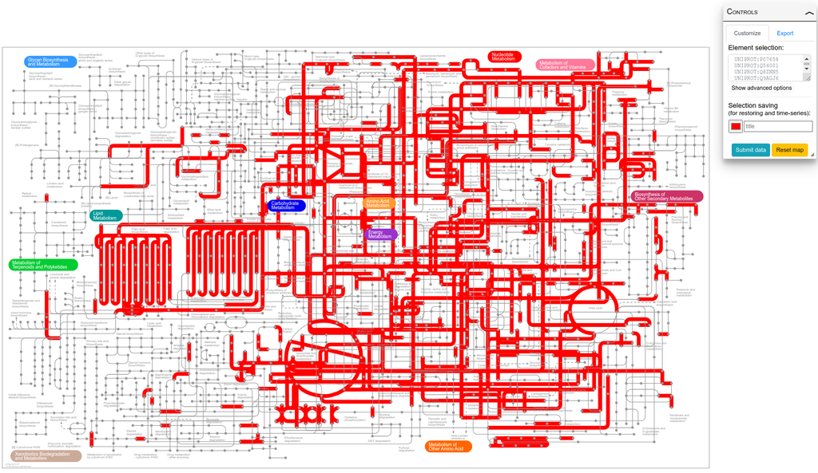

## Visualising in KEGG

Visualising in KEGG ( the Kyoto Encyclopedia of Genes and Genomes) allows us to zoom in further into the metabolism. The best way to approach this, is to take all protein sequences produced by prokka (the `.faa file`) and do a protein blast to the KEGG database with [blastKOala](https://www.kegg.jp/blastkoala/). This takes quite some time and requires an account, so I did this for you already. The files are available in the `data/blastKOala` directory. Note that the bin numbers may not match up between my example and your own run, this is just for illustration of what's possible with the method.

**[DO:] Upload and visualise these simple tables on [KEGG reconstruct pathway](https://www.genome.jp/kegg/mapper/reconstruct.html)**

You may feel overwhelmed by the number of pathways, modules and genes available to you. For this specific case, we are interested in Nitrogen metabolism. You may have a look at the Dijkhuizen et al. 2018 paper on Azolla endophytes. Figure 4 of that paper shows the nitrogen metabolism of multiple microbes is plotted. Next, some hypotheses are derived and tested in the wet lab. Does your plot of the nitrogen metabolism overlap with the one published? Or did you maybe discover a new endophyte!

http://www.genome.jp/kegg/tool/map_module.html

```bash
ls data/blastKOala -1
```

```
bin_1_KO.txt
bin_2_KO.txt
bin_3_KO.txt
bin_4_KO.txt
bin_5_KO.txt
bin_6_KO.txt
KO_combined.txt
```

A snapshot of the KEGG nitrogen metabolism pathway looks like this (with the `KO_combined.txt` file as input).

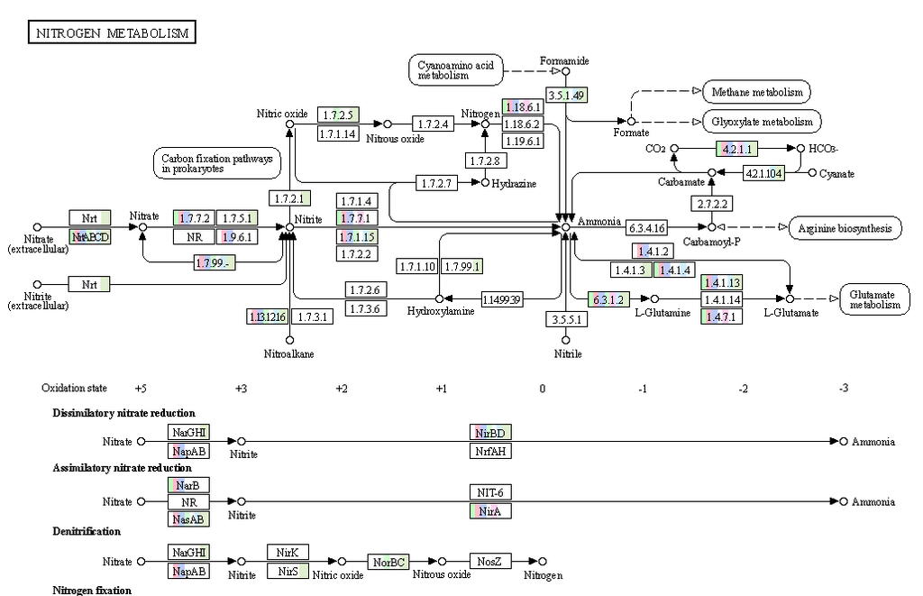